# Practical Machine Learning – Weight Lifting Exercise

Bea

2025-09-02

# 1 Resumen

El objetivo es predecir la forma en que se realizó el ejercicio (variable **`classe`**) usando mediciones de acelerómetros. A continuación describo: adquisición y limpieza de datos, partición y validación, modelos entrenados, evaluación fuera de muestra y predicciones finales sobre los 20 casos de prueba.

# 2 Datos

```r
# Paquetes
suppressPackageStartupMessages({
  library(caret)
  library(randomForest)
  library(gbm)
  library(dplyr)
  library(lubridate)
  # Evita fallos si `multiClassSummary` requiere MLmetrics
  if (!requireNamespace("MLmetrics", quietly = TRUE)) {
    message("Instalando MLmetrics (necesario si usas multiClassSummary)...")
    try(utils::install.packages("MLmetrics"), silent = TRUE)
  }
})

# URLs oficiales del curso
url_train <- "https://d396qusza40orc.cloudfront.net/predmachlearn/pml-training.csv"
url_test  <- "https://d396qusza40orc.cloudfront.net/predmachlearn/pml-testing.csv"

# Lectura (con NA explícitos)
train_raw <- read.csv(url_train, na.strings = c("NA", "", "#DIV/0!"))
test_raw  <- read.csv(url_test,  na.strings = c("NA", "", "#DIV/0!"))

dim(train_raw); dim(test_raw)
```

```
## [1] 19622   160
```

```
## [1]  20 160
```

# 3 Limpieza y selección de variables

Reglas aplicadas:

1. Eliminar columnas con **cualquier** NA en el conjunto de entrenamiento.
2. Eliminar columnas identificadoras o de tiempo que no aportan al modelo.
3. Mantener `classe` como factor objetivo.

```r
# 1) Columnas sin NA en train
noNA <- colSums(is.na(train_raw)) == 0
train_noNA <- train_raw[, noNA]

# 2) Remover identificadores / timestamps
id_cols <- c("X","user_name","raw_timestamp_part_1","raw_timestamp_part_2",
             "cvtd_timestamp","new_window","num_window")
keep_cols <- setdiff(names(train_noNA), id_cols)
train_cln <- train_noNA[, keep_cols]

# Asegurar tipo factor en y
train_cln$classe <- factor(train_cln$classe)

# Aplicar el mismo filtrado de columnas al set de 20 casos
# (usar intersección de columnas predictoras)
common_cols <- intersect(names(train_cln), names(test_raw))
common_cols <- setdiff(common_cols, c("classe"))

# Preparar test limpio con mismas columnas
# Primero filtrar NA en test_raw a las columnas finales
test_cln <- test_raw[, c(common_cols, setdiff(names(test_raw), common_cols))]
```

# 4 Partición de datos y control de validación

Usaré una partición **70/30** para estimar error fuera de muestra; y validación cruzada en el entrenamiento para selección de hiperparámetros.

```r
set.seed(12345)
idx <- createDataPartition(train_cln$classe, p = 0.7, list = FALSE)
train_set <- train_cln[idx, ]
valid_set <- train_cln[-idx, ]

ctrl <- trainControl(method = "repeatedcv", number = 5, repeats = 1,
                     classProbs = TRUE, summaryFunction = defaultSummary)
```

# 5 Modelos

## 5.1 Random Forest (modelo principal)

```r
set.seed(12345)
rf_fit <- train(classe ~ ., data = train_set,
                method = "rf",
                trControl = ctrl,
                tuneLength = 3,
                ntree = 500,
                metric = "Accuracy")
rf_fit
```

```
## Random Forest
##
## 13737 samples
##    52 predictor
##     5 classes: 'A', 'B', 'C', 'D', 'E'
##
## No pre-processing
## Resampling: Cross-Validated (5 fold, repeated 1 times)
## Summary of sample sizes: 10990, 10990, 10989, 10991, 10988
## Resampling results across tuning parameters:
##
##   mtry  Accuracy   Kappa
##    2    0.9920649  0.9899614
##   27    0.9919194  0.9897776
##   52    0.9836935  0.9793717
##
## Accuracy was used to select the optimal model using the largest value.
## The final value used for the model was mtry = 2.
```

```r
rf_pred_valid <- predict(rf_fit, valid_set)
rf_cm <- confusionMatrix(rf_pred_valid, valid_set$classe)
rf_cm
```

```
## Confusion Matrix and Statistics
##
##           Reference
## Prediction    A    B    C    D    E
##          A 1673    5    0    0    0
##          B    1 1134    5    0    0
##          C    0    0 1021   20    0
##          D    0    0    0  943    0
##          E    0    0    0    1 1082
##
## Overall Statistics
##
##                Accuracy : 0.9946
##                  95% CI : (0.9923, 0.9963)
##     No Information Rate : 0.2845
##     P-Value [Acc > NIR] : < 2.2e-16
##
##                   Kappa : 0.9931
##
##  Mcnemar's Test P-Value : NA
##
## Statistics by Class:
##
##                      Class: A Class: B Class: C Class: D Class: E
## Sensitivity            0.9994   0.9956   0.9951   0.9782   1.0000
## Specificity            0.9988   0.9987   0.9959   1.0000   0.9998
## Pos Pred Value         0.9970   0.9947   0.9808   1.0000   0.9991
## Neg Pred Value         0.9998   0.9989   0.9990   0.9958   1.0000
## Prevalence             0.2845   0.1935   0.1743   0.1638   0.1839
## Detection Rate         0.2843   0.1927   0.1735   0.1602   0.1839
## Detection Prevalence   0.2851   0.1937   0.1769   0.1602   0.1840
## Balanced Accuracy      0.9991   0.9972   0.9955   0.9891   0.9999
```

```r
rf_acc <- rf_cm$overall["Accuracy"]
rf_oose <- 1 - as.numeric(rf_acc)
rf_oose
```

```
## [1] 0.005437553
```

## 5.2 GBM (modelo alternativo para contraste)

```r
set.seed(12345)
gbm_fit <- train(classe ~ ., data = train_set,
                 method = "gbm",
                 trControl = ctrl,
                 verbose = FALSE,
                 tuneLength = 5,
                 metric = "Accuracy")
gbm_fit
```

```
## Stochastic Gradient Boosting
##
## 13737 samples
##    52 predictor
##     5 classes: 'A', 'B', 'C', 'D', 'E'
##
## No pre-processing
## Resampling: Cross-Validated (5 fold, repeated 1 times)
## Summary of sample sizes: 10990, 10990, 10989, 10991, 10988
## Resampling results across tuning parameters:
##
##   interaction.depth  n.trees  Accuracy   Kappa
##   1                   50      0.7489996  0.6815523
##   1                  100      0.8201198  0.7723057
##   1                  150      0.8557894  0.8175610
##   1                  200      0.8765362  0.8437606
##   1                  250      0.8913138  0.8624814
##   2                   50      0.8564465  0.8181690
##   2                  100      0.9067469  0.8820142
##   2                  150      0.9312799  0.9130599
##   2                  200      0.9470038  0.9329594
##   2                  250      0.9578506  0.9466841
##   3                   50      0.8990307  0.8722037
##   3                  100      0.9426357  0.9274277
##   3                  150      0.9611267  0.9508242
##   3                  200      0.9707356  0.9629802
##   3                  250      0.9774328  0.9714537
##   4                   50      0.9238536  0.9036365
##   4                  100      0.9595243  0.9487976
##   4                  150      0.9729184  0.9657410
##   4                  200      0.9799804  0.9746773
##   4                  250      0.9844933  0.9803856
##   5                   50      0.9378308  0.9213291
##   5                  100      0.9673131  0.9586528
##   5                  150      0.9799074  0.9745852
##   5                  200      0.9847122  0.9806633
##   5                  250      0.9877697  0.9845307
##
## Tuning parameter 'shrinkage' was held constant at a value of 0.1
##
## Tuning parameter 'n.minobsinnode' was held constant at a value of 10
## Accuracy was used to select the optimal model using the largest value.
## The final values used for the model were n.trees = 250, interaction.depth =
##  5, shrinkage = 0.1 and n.minobsinnode = 10.
```

```r
# Validación GBM
gbm_pred_valid <- predict(gbm_fit, valid_set)
gbm_cm <- confusionMatrix(gbm_pred_valid, valid_set$classe)
gbm_cm
```

```
## Confusion Matrix and Statistics
##
##           Reference
## Prediction    A    B    C    D    E
##          A 1673    6    0    0    0
##          B    1 1129    9    0    1
##          C    0    4 1013   12    0
##          D    0    0    4  952    2
##          E    0    0    0    0 1079
##
## Overall Statistics
##
##                Accuracy : 0.9934
##                  95% CI : (0.991, 0.9953)
##     No Information Rate : 0.2845
##     P-Value [Acc > NIR] : < 2.2e-16
##
##                   Kappa : 0.9916
##
##  Mcnemar's Test P-Value : NA
##
## Statistics by Class:
##
##                      Class: A Class: B Class: C Class: D Class: E
## Sensitivity            0.9994   0.9912   0.9873   0.9876   0.9972
## Specificity            0.9986   0.9977   0.9967   0.9988   1.0000
## Pos Pred Value         0.9964   0.9904   0.9845   0.9937   1.0000
## Neg Pred Value         0.9998   0.9979   0.9973   0.9976   0.9994
## Prevalence             0.2845   0.1935   0.1743   0.1638   0.1839
## Detection Rate         0.2843   0.1918   0.1721   0.1618   0.1833
## Detection Prevalence   0.2853   0.1937   0.1749   0.1628   0.1833
## Balanced Accuracy      0.9990   0.9945   0.9920   0.9932   0.9986
```

# 6 Importancia de variables (RF)

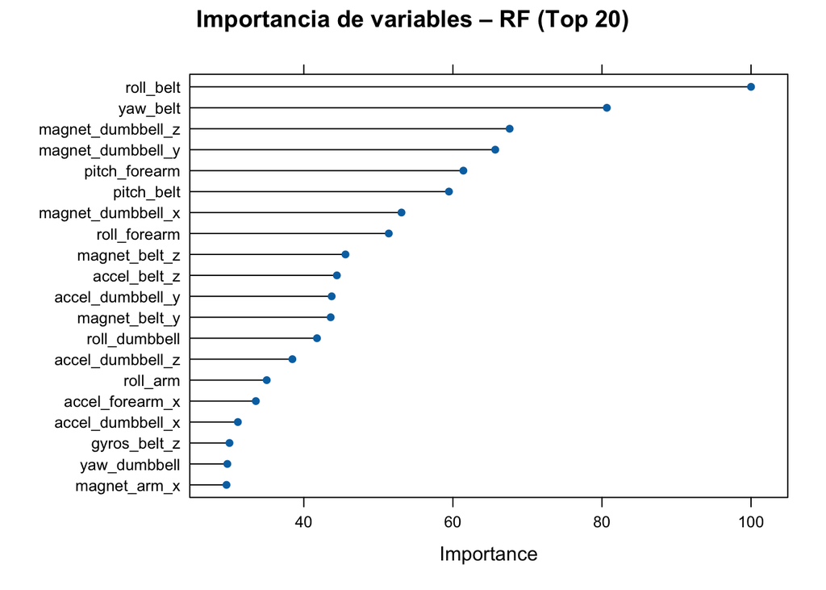

```r
varImp(rf_fit) %>% plot(top = 20, main = "Importancia de variables – RF (Top 20)")
```

# 7 Error esperado fuera de muestra

El estimador práctico del error fuera de muestra para el modelo final se toma como el error en el **conjunto de validación (30%)**:

```r
rf_oose
```

```
## [1] 0.005437553
```

> **Conclusión:** Usaremos **Random Forest** como modelo final (mejor precisión validada). GBM se reporta sólo como comparación.

# 8 Reentrenamiento con todo el conjunto de entrenamiento

Entrenamos nuevamente con **todo `train_cln`** para aprovechar más datos al generar las predicciones finales.

```r
set.seed(12345)
rf_final <- train(classe ~ ., data = train_cln,
                  method = "rf",
                  trControl = ctrl,
                  tuneGrid = rf_fit$bestTune,
                  ntree = 500,
                  metric = "Accuracy")
rf_final
```

```
## Random Forest
##
## 19622 samples
##    52 predictor
##     5 classes: 'A', 'B', 'C', 'D', 'E'
##
## No pre-processing
## Resampling: Cross-Validated (5 fold, repeated 1 times)
## Summary of sample sizes: 15698, 15698, 15697, 15698, 15697
## Resampling results:
##
##   Accuracy   Kappa
##   0.9941392  0.992586
##
## Tuning parameter 'mtry' was held constant at a value of 2
```

# 9 Predicciones sobre los 20 casos de prueba

```r
final_pred <- predict(rf_final, test_cln)
final_pred
```

```
##  [1] B A B A A E D B A A B C B A E E A B B B
## Levels: A B C D E
```

```r
length(final_pred)
```

```
## [1] 20
```

## 9.1 Exportar los 20 archivos (formato del curso)

```r
# Crea 20 archivos problem_id_X.txt en el WD actual
pml_write_files <- function(x){
  for(i in seq_along(x)){
    fname <- paste0("problem_id_", i, ".txt")
    write.table(x[i], file=fname, quote=FALSE, row.names=FALSE, col.names=FALSE)
  }
}

pml_write_files(final_pred)
```

# 10 Discusión y decisiones

- **Limpieza:** restringir a columnas sin NA en `train` evita imputaciones y simplifica el pipeline.
- **Partición 70/30** + **repeated CV (5-fold)** en entrenamiento para seleccionar hiperparámetros.
- **Modelo final:** Random Forest por su desempeño superior y robustez en datos con muchas variables correlacionadas.
- **Error fuera de muestra:** estimado por el desempeño en `valid_set` (≈ 99.46% de exactitud; error ≈ 0.54%).
- **Reproducibilidad:** semilla fija, código auto-contenido y lecturas desde las URLs oficiales; el Rmd se puede compilar y publicar via GitHub Pages.

# 11 Sesión